# EXPLORATORY DATA ANALYSIS BY SHRISHTI

Our project is to analyse which factors affect most to health status of people.Health of peaople is analysed on basis of different characteristics like age factor,financial status of person, race and hispanic origin of person , gender etc.

The data set has 12 variables.One variable is of characteristics on which basis health status is claculated and other varibles are showing percentage of health status and standard error .

[figure not shown]

## DATA DESCRIPTION

Dataset is of health status on basis of selected characteristics which effect or responsible for health status of person.Dataset have 12 data variables.One input variable is of characteristics oh which basis heath status of person is clasified as excellent, good ,poor etc. Other 11 variables shows status heath status estimate and error.Standard error estimates were calculated using replicate weights,'Fay's method'.

## ATTRIBUTE INFORMATION

Following are the input variables in dataset:

1. Characteristics
2. Total_number
3. Excellent_estimate
4. Excellent_standard
5. very_good_estimate
6. very_good_standard
7. good_estimate
8. good_standard
9. Fair_estimate
10. Fair_standard_error
11. Poor_estimate
12. Poor_standard_error

```python
from IPython.display import HTML

HTML('''<script>
code_show=true;
function code_toggle() {
 if (code_show){
 $('div.input').hide();
 } else {
 $('div.input').show();
 }
 code_show = !code_show
}
$( document ).ready(code_toggle);
</script>
<form action="javascript:code_toggle()"><input type="submit" value="Click here to toggle on/off the raw code."></form>''')
```

#### Importing libraries needed for data manupilation and visulization

```python
import pandas as pd
import numpy as np
import seaborn as sns
import matplotlib.pyplot as plt
%matplotlib inline
import matplotlib.patches as mpatches
```

#### Importing dataset using Excelfile function in pandas library

```python
df=pd.ExcelFile("E:\\2002.xls")
```

#### File named as 2002 have mutilple sheets. Here we just check the sheetnames in file

```python
df.sheet_names
```

```
[u'Table 1.', u'Table 2.', u'Table 3.', u'Table 4.', u'Table 5.', u'Table 6.']
```

#### Creating dataframe of sheetname=Table 1. and printing first two rows of dataframe. Skip rows =7 just skip first 7 rows because is dos not conatin any useful data.

```python
df1 = df.parse(sheetname='Table 1.', skiprows=7)
df1.head(2)
```

|  | Sex | Unnamed: 1 | Unnamed: 2 | Unnamed: 3 | Unnamed: 4 | Unnamed: 5 | Unnamed: 6 | Unnamed: 7 | Unnamed: 8 | Unnamed: 9 | Unnamed: 10 | Unnamed: 11 | Unnamed: 12 | Unnamed: 13 | Unnamed: 14 |
| --- | --- | --- | --- | --- | --- | --- | --- | --- | --- | --- | --- | --- | --- | --- | --- |
| 0 | .Male | 138694.083 | 36.418673 | 0.412961 | 30.858724 | 0.417889 | 22.377070 | 0.369498 | 7.254938 | 0.154421 | 3.090595 | 0.100008 | NaN | NaN | NaN |
| 1 | .Female | 145056.841 | 32.912664 | 0.433130 | 30.331737 | 0.350341 | 24.465991 | 0.334111 | 8.730050 | 0.161803 | 3.559558 | 0.102160 | NaN | NaN | NaN |

```python
print("Shape of dataset:")
df1.shape
```

```
Shape of dataset:
```

```
(29, 15)
```

```python
print("size of dataset:")
df1.size
```

```
size of dataset:
```

```
435
```

#### Describing all statistical parameters of dataset using describe function

```python
df1.describe(include="all")
```

|  | Sex | Unnamed: 1 | Unnamed: 2 | Unnamed: 3 | Unnamed: 4 | Unnamed: 5 | Unnamed: 6 | Unnamed: 7 | Unnamed: 8 | Unnamed: 9 | Unnamed: 10 | Unnamed: 11 | Unnamed: 12 | Unnamed: 13 | Unnamed: 14 |
| --- | --- | --- | --- | --- | --- | --- | --- | --- | --- | --- | --- | --- | --- | --- | --- |
| count | 29 | 21.000000 | 21.000000 | 21.000000 | 21.000000 | 21.000000 | 21.000000 | 21.000000 | 21.000000 | 21.000000 | 21.000000 | 21.000000 | 0.0 | 0.0 | 1 |
| unique | 29 | NaN | NaN | NaN | NaN | NaN | NaN | NaN | NaN | NaN | NaN | NaN | NaN | NaN | 1 |
| top | .65 years and over | NaN | NaN | NaN | NaN | NaN | NaN | NaN | NaN | NaN | NaN | NaN | NaN | NaN |  |
| freq | 1 | NaN | NaN | NaN | NaN | NaN | NaN | NaN | NaN | NaN | NaN | NaN | NaN | NaN | 1 |
| mean | NaN | 97894.651452 | 33.350060 | 0.621801 | 30.285538 | 0.568274 | 24.247633 | 0.519240 | 8.554992 | 0.264604 | 3.561777 | 0.162759 | NaN | NaN | NaN |
| std | NaN | 70735.825366 | 8.889109 | 0.242860 | 3.249220 | 0.192346 | 4.218850 | 0.203451 | 4.146667 | 0.134240 | 2.425378 | 0.090547 | NaN | NaN | NaN |
| min | NaN | 13845.833500 | 9.177291 | 0.360338 | 20.547665 | 0.350341 | 13.594020 | 0.329901 | 1.511113 | 0.117162 | 0.334431 | 0.052166 | NaN | NaN | NaN |
| 25% | NaN | 40464.573100 | 30.180174 | 0.414761 | 27.927679 | 0.398425 | 22.377070 | 0.365456 | 6.488889 | 0.158453 | 2.247705 | 0.099849 | NaN | NaN | NaN |
| 50% | NaN | 72791.826500 | 33.153485 | 0.525472 | 31.250895 | 0.530721 | 24.465991 | 0.440245 | 7.878962 | 0.251146 | 3.090595 | 0.125585 | NaN | NaN | NaN |
| 75% | NaN | 145056.841000 | 36.418673 | 0.788628 | 32.331439 | 0.638904 | 26.205765 | 0.613168 | 10.251152 | 0.330600 | 4.364076 | 0.194824 | NaN | NaN | NaN |
| max | NaN | 249873.794000 | 56.632756 | 1.271385 | 35.285035 | 1.041917 | 35.755852 | 1.061663 | 22.651021 | 0.573847 | 11.868171 | 0.374147 | NaN | NaN | NaN |

#### Checking for null values in dataset

```python
print("checking for null values:")
df1.isnull().sum()
```

```
checking for null values:
```

```
Sex             0
Unnamed: 1      8
Unnamed: 2      8
Unnamed: 3      8
Unnamed: 4      8
Unnamed: 5      8
Unnamed: 6      8
Unnamed: 7      8
Unnamed: 8      8
Unnamed: 9      8
Unnamed: 10     8
Unnamed: 11     8
Unnamed: 12    29
Unnamed: 13    29
Unnamed: 14    28
dtype: int64
```

```python
df1=df1.drop(['Unnamed: 12','Unnamed: 13','Unnamed: 14'],axis=1)
df1.head()
```

|  | Sex | Unnamed: 1 | Unnamed: 2 | Unnamed: 3 | Unnamed: 4 | Unnamed: 5 | Unnamed: 6 | Unnamed: 7 | Unnamed: 8 | Unnamed: 9 | Unnamed: 10 | Unnamed: 11 |
| --- | --- | --- | --- | --- | --- | --- | --- | --- | --- | --- | --- | --- |
| 0 | .Male | 138694.0830 | 36.418673 | 0.412961 | 30.858724 | 0.417889 | 22.377070 | 0.369498 | 7.254938 | 0.154421 | 3.090595 | 0.100008 |
| 1 | .Female | 145056.8410 | 32.912664 | 0.433130 | 30.331737 | 0.350341 | 24.465991 | 0.334111 | 8.730050 | 0.161803 | 3.559558 | 0.102160 |
| 2 | Race and Hispanic origin\2 | NaN | NaN | NaN | NaN | NaN | NaN | NaN | NaN | NaN | NaN | NaN |
| 3 | .White, non-Hispanic | 197582.6650 | 35.276824 | 0.422826 | 31.253977 | 0.394558 | 22.413618 | 0.355545 | 7.686472 | 0.158453 | 3.369109 | 0.097852 |
| 4 | .Black, non-Hispanic | 34097.6796 | 29.833356 | 0.819319 | 29.781121 | 0.791402 | 26.092022 | 0.725068 | 10.131911 | 0.381302 | 4.161590 | 0.272525 |

#### Reaname all input data variables and dropping rows which have null values and Reset index after dropping rows which have null values

```python
df2= df1.rename(index=str, columns={"Sex":"Characteristics","Unnamed: 1":"Toatl_number" ,"Unnamed: 2":"Excellent_estimate","Unnamed: 3":"Excellent_standard","Unnamed: 4":"very_good_estimate","Unnamed: 5":"very_good_standard","Unnamed: 6":"good_estimate","Unnamed: 7":"good_standard","Unnamed: 8":"fair_estimate","Unnamed: 9":"Fair_standard_error","Unnamed: 10":"poor_estimate","Unnamed: 11":"poor_standard_error"})
df2=df2.drop(df2.index[[2,7,24,25,26,27,28,16]])
df2=df2.reset_index(drop=True)
```

#### Printing first five rows of dataframe

```python
df2.head()
```

|  | Characteristics | Toatl_number | Excellent_estimate | Excellent_standard | very_good_estimate | very_good_standard | good_estimate | good_standard | fair_estimate | Fair_standard_error | poor_estimate | poor_standard_error |
| --- | --- | --- | --- | --- | --- | --- | --- | --- | --- | --- | --- | --- |
| 0 | .Male | 138694.0830 | 36.418673 | 0.412961 | 30.858724 | 0.417889 | 22.377070 | 0.369498 | 7.254938 | 0.154421 | 3.090595 | 0.100008 |
| 1 | .Female | 145056.8410 | 32.912664 | 0.433130 | 30.331737 | 0.350341 | 24.465991 | 0.334111 | 8.730050 | 0.161803 | 3.559558 | 0.102160 |
| 2 | .White, non-Hispanic | 197582.6650 | 35.276824 | 0.422826 | 31.253977 | 0.394558 | 22.413618 | 0.355545 | 7.686472 | 0.158453 | 3.369109 | 0.097852 |
| 3 | .Black, non-Hispanic | 34097.6796 | 29.833356 | 0.819319 | 29.781121 | 0.791402 | 26.092022 | 0.725068 | 10.131911 | 0.381302 | 4.161590 | 0.272525 |
| 4 | .Other, non-Hispanic | 13845.8335 | 35.243711 | 1.271385 | 31.900879 | 0.918349 | 23.136261 | 1.061663 | 7.370736 | 0.547394 | 2.348412 | 0.317444 |

#### Shape of dataset after cleaning

```python
print("Shape of dataset after preprocessing")
df2.shape
```

```
Shape of dataset after preprocessing
```

```
(21, 12)
```

#### Size of dataset

```python
df2.size
```

```
252
```

#### Description of statistical parameters using describe function after cleaning

```python
df2.describe(include="all")
```

|  | Characteristics | Toatl_number | Excellent_estimate | Excellent_standard | very_good_estimate | very_good_standard | good_estimate | good_standard | fair_estimate | Fair_standard_error | poor_estimate | poor_standard_error |
| --- | --- | --- | --- | --- | --- | --- | --- | --- | --- | --- | --- | --- |
| count | 21 | 21.000000 | 21.000000 | 21.000000 | 21.000000 | 21.000000 | 21.000000 | 21.000000 | 21.000000 | 21.000000 | 21.000000 | 21.000000 |
| unique | 21 | NaN | NaN | NaN | NaN | NaN | NaN | NaN | NaN | NaN | NaN | NaN |
| top | .65 years and over | NaN | NaN | NaN | NaN | NaN | NaN | NaN | NaN | NaN | NaN | NaN |
| freq | 1 | NaN | NaN | NaN | NaN | NaN | NaN | NaN | NaN | NaN | NaN | NaN |
| mean | NaN | 97894.651452 | 33.350060 | 0.621801 | 30.285538 | 0.568274 | 24.247633 | 0.519240 | 8.554992 | 0.264604 | 3.561777 | 0.162759 |
| std | NaN | 70735.825366 | 8.889109 | 0.242860 | 3.249220 | 0.192346 | 4.218850 | 0.203451 | 4.146667 | 0.134240 | 2.425378 | 0.090547 |
| min | NaN | 13845.833500 | 9.177291 | 0.360338 | 20.547665 | 0.350341 | 13.594020 | 0.329901 | 1.511113 | 0.117162 | 0.334431 | 0.052166 |
| 25% | NaN | 40464.573100 | 30.180174 | 0.414761 | 27.927679 | 0.398425 | 22.377070 | 0.365456 | 6.488889 | 0.158453 | 2.247705 | 0.099849 |
| 50% | NaN | 72791.826500 | 33.153485 | 0.525472 | 31.250895 | 0.530721 | 24.465991 | 0.440245 | 7.878962 | 0.251146 | 3.090595 | 0.125585 |
| 75% | NaN | 145056.841000 | 36.418673 | 0.788628 | 32.331439 | 0.638904 | 26.205765 | 0.613168 | 10.251152 | 0.330600 | 4.364076 | 0.194824 |
| max | NaN | 249873.794000 | 56.632756 | 1.271385 | 35.285035 | 1.041917 | 35.755852 | 1.061663 | 22.651021 | 0.573847 | 11.868171 | 0.374147 |

##### checking for null values after cleaning of data.

our dataset is now clean and can be used for EDA

```python
print("Checking for null values if any remain in dataset")
df2.isnull().sum()
```

```
Checking for null values if any remain in dataset
```

```
Characteristics        0
Toatl_number           0
Excellent_estimate     0
Excellent_standard     0
very_good_estimate     0
very_good_standard     0
good_estimate          0
good_standard          0
fair_estimate          0
Fair_standard_error    0
poor_estimate          0
poor_standard_error    0
dtype: int64
```

## UNIVARIATE ANALYSIS

Univariate is simplest way of analyzing data.'Uni' means one implies that we only analyze one variable at a time. Univariate plots gives us the ideas of present outlliers in data and it also helps in bivariate and multivariate analysis. Plots like barplot,histogram,boxplot,distribution plot etc are generally used for univariate analysis.

Barplot are generally plot for oridinal data and histrogram ,distribution etc are plot for continuous data variables.

### HEALTH STATUS PLOT ON BASIS OF GENDER CHARACTERISTICS

### MALE-COUNTPLOT

Here's is the bar plot of heath status variables for male

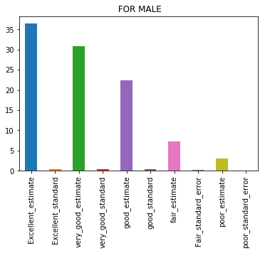

```python
row = df2.iloc[0,2:]
row.plot(kind='bar',title=" FOR MALE")
plt.show()
```

Following trends are observable from above plot:

1. Male have high % of excellent_estimtate which is approximately 36%
2. Poor Health status is very less approx 3%
3. Graph shows decreasing trend in health status for male.

### FEMALE-COUNTPLOT

Here's is barplot of health status for female

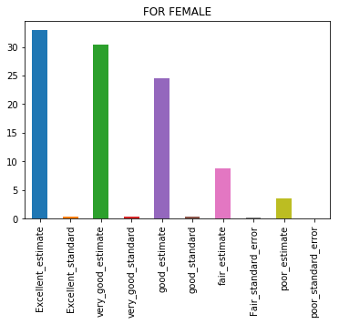

```python
row = df2.iloc[1,2:]
row.plot(kind='bar',title="FOR FEMALE")
plt.show()
```

### HEALTH STATUS PLOT ON BASIS OF RACE AND HISPANIC ORIGIN

### White non hispanic

Here's barplot of health status for white non hispanic

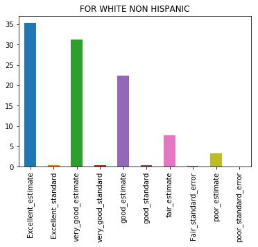

```python
row = df2.iloc[2,2:]
row.plot(kind='bar',title="FOR WHITE NON HISPANIC")
plt.show()
```

Following trends can be observed form above plot:

1. The graph shows decreasing trends i.e people have high excellent health status as compared to poor health status.
2. excellent health estimate % is approx. 35% for white non hispanic characteritics.
3. As we can see from above plot , good_estimate have 22% approx which is not a good percentage.

### Black non hispanic

Here's barplot of heath status for black non hispanic characyeristic

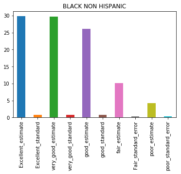

```python
row = df2.iloc[3,2:]
row.plot(kind='bar',title="BLACK NON HISPANIC")
plt.show()
```

Following findings are findout from above plot:

1. The graph shows decreasing trends i.e people have high excellent health status as compared to poor health status.
2. excellent health estimate % is approx. 30% for black non hispanic characteritics.
3. As we can see from above plot , good_estimate have 25% approx which is not a good percentage.

### For other non hispanic

Here's barplot zhowing heath status percentage on the basis of race characteristics

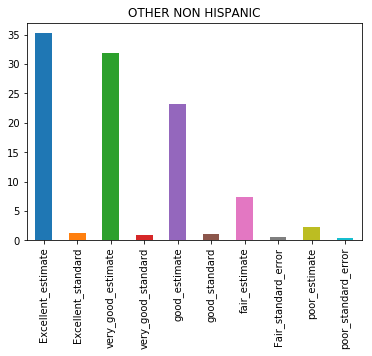

```python
row = df2.iloc[4,2:]
row.plot(kind='bar',title="OTHER NON HISPANIC")
plt.show()
```

Following trends or variation can be observed from above plot:

1. The graph shows decreasing trends i.e people have high excellent health status as compared to poor health status.
2. excellent health estimate % is approx. 35% for other non hispanic characteritics.
3. As we can see from above plot , good_estimate have 23% approx which is not a good percentage.
4. Poor health estimate is very less approx 2.5% which shows people with poor heath status are very les.

### Hispanic

Here's barplot showing heath status on basis on characteristics

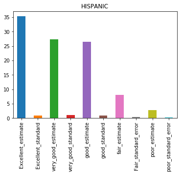

```python
row = df2.iloc[5,2:]
row.plot(kind='bar',title="HISPANIC")
plt.show()
```

Following trends can be observed from above plot:

1. The graph shows decreasing trends i.e people have high excellent health status as compared to poor health status.
2. Excellent health estimate % is approx. 35% for white hispanic characteritics.
3. As we can see from above plot , good_estimate have 26% approx which is not quiet appreciable.

### PLOTS ON BASIS ON AGE CHARACTERISTICS

### Under 18 years

Here's barplot showing health status percentage for people under 18 years.

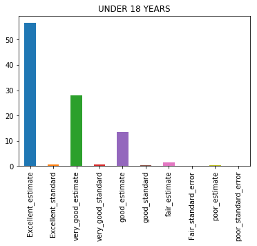

```python
row = df2.iloc[6,2:]
row.plot(kind='bar',title="UNDER 18 YEARS")
plt.show()
```

Following trends can be observed from above plot:

1. Poor estimalte for health status have negiligible % for people under 18 years.
2. Excellent heath status have % approx 55% for under 18 years.
3. Standard error for all health status is negligible which show data is more accurate.

### 18 years and older

Here's barplot showing heath status percentage on considering age .

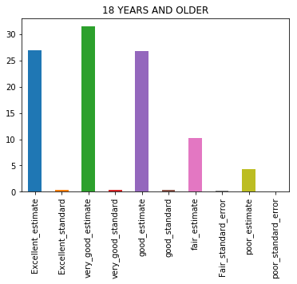

```python
row = df2.iloc[7,2:]
row.plot(kind='bar',title="18 YEARS AND OLDER")
plt.show()
```

Infernces from above plot:

1. Poor estimalte for health status have % approx of 5% for people older than 18 years.
2. Excellent heath status have % approx 25% for people older than 18 years which is low .
3. Standard error for all health status is negligible which show data is more accurate.

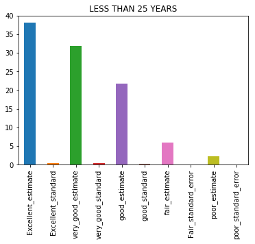

```python
row = df2.iloc[8,2:]
row.plot(kind='bar',title="LESS THAN 25 YEARS")
plt.show()
```

### 18-24 Years

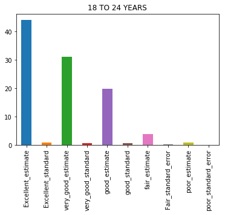

```python
row = df2.iloc[9,2:]
row.plot(kind='bar',title="18 TO 24 YEARS")
plt.show()
```

Following trends are observable from above plot:

### 25-44 years

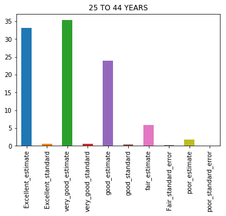

```python
row = df2.iloc[10,2:]
row.plot(kind='bar',title="25 TO 44 YEARS")
plt.show()
```

### 45-64 years

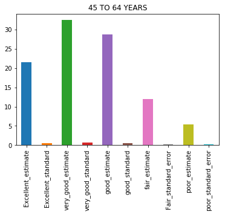

```python
row = df2.iloc[11,2:]
row.plot(kind='bar',title="45 TO 64 YEARS")
plt.show()
```

Following trends are observable from above plot:

1. Excellent health status percentage is less as compared to very good and good health status.
2. Percentage for poor health status is quite high aprox 5%.
3. Very good estimate health have higher percentage .

### 18-64 years

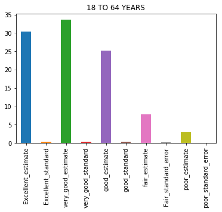

```python
row = df2.iloc[12,2:]
row.plot(kind='bar',title="18 TO 64 YEARS")
plt.show()
```

### 65 years and over

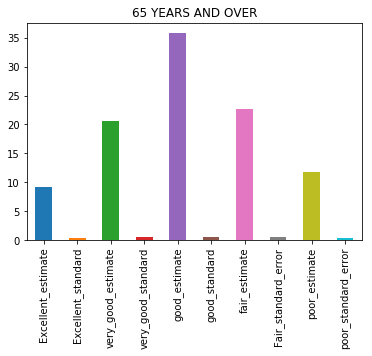

```python
row = df2.iloc[13,2:]
row.plot(kind='bar',title="65 YEARS AND OVER")
plt.show()
```

Following trends are observable from above plot:

1. Poor health status percetage is quite high approx 12%.
2. Most peolple, older than 65 years have good health staus.

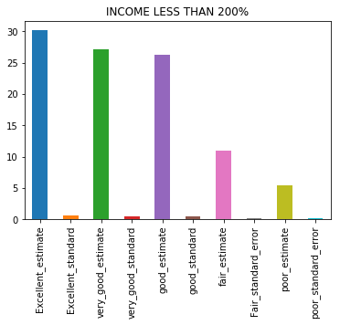

```python
row = df2.iloc[14,2:]
row.plot(kind='bar',title="INCOME LESS THAN 200%")
plt.show()
```

### Income less than 100%(poverty) plot

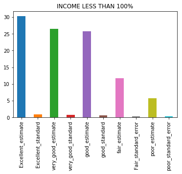

```python
row = df2.iloc[15,2:]
row.plot(kind='bar',title="INCOME LESS THAN 100%")
plt.show()
```

Following trends are observable from above plot:

1. Poor health status percentage is high approx. 6%.
2. More number of people have exccellent health status than others health status.

### Income b/w 100% - 200% plot

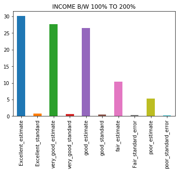

```python
row = df2.iloc[16,2:]
row.plot(kind='bar',title="INCOME B/W 100% TO 200%")
plt.show()
```

Following trends are observable from above plot:

1. More number of peolple have excellent health status, whose income is b/w 100%-200%
2. Approx 6% of people have poor health status.
3. Standard error for poor health is less as compared to other health status.

### Income more than 200%

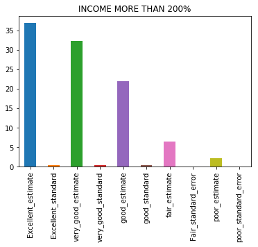

```python
row = df2.iloc[17,2:]
row.plot(kind='bar',title="INCOME MORE THAN 200%")
plt.show()
```

Following trends are observable from above plot:

1. More number of peolple have exellent health status approx 36% population , whose income is more than 200%
2. Approx 3% of people have poor health status.
3. Standard error for poor health is negligible .

### 200% to less than 300%

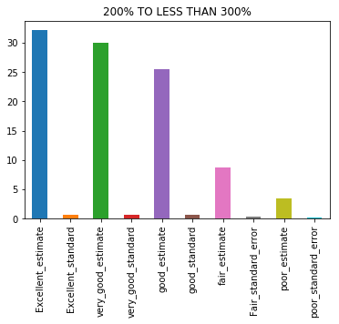

```python
row = df2.iloc[18,2:]
row.plot(kind='bar',title="200% TO LESS THAN 300%")
plt.show()
```

Following trends are observable from above plot:

1. Health status percnetage for excellent and very good shows little variation.
2. Less number of people have poor health status.

### Income more than 300% less than 400%

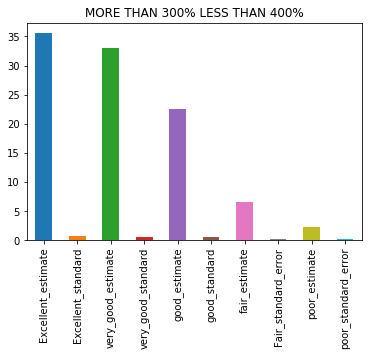

```python
row = df2.iloc[19,2:]
row.plot(kind='bar',title="MORE THAN 300% LESS THAN 400%")
plt.show()
```

Following trends are observable from above plot:

1. More number of people have excellent health status.
2. Less number of people have poor health status.

### 400% OR HIGHER INCOME PLOT

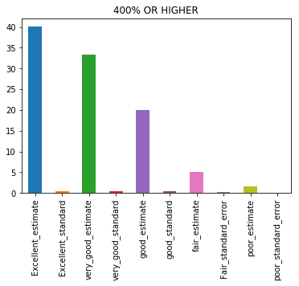

```python
row = df2.iloc[20,2:]
row.plot(kind='bar',title="400% OR HIGHER")
plt.show()
```

Followings trends are observable from above plot:

1. Excelent health status percentage is approx 40% for people ,who have income more than 400%.
2. Less number of people have poor health status.

## BIVARIATE ANALYSIS:

Bivariate analysis is one of the simplest forms of statistical analysis. it involves the analysis of two variables(often denoted as X,Y) for the purpose to determine the relationship b/w different quantities.

### MALE VS FEMALE PLOT FOR HEALTH STATUS

Here's barplot for male Vs female show variation in health status

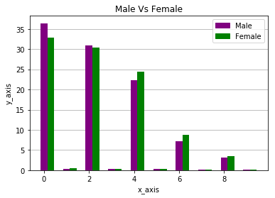

```python
row=df2.iloc[0,2:]
row1=df2.iloc[1,2:]
N=10
ind = np.arange(N)
bar_width=0.3
plt.bar(ind,row,width=bar_width, color='purple',zorder=2)
plt.bar(ind+bar_width,row1, width=bar_width, color='green',zorder=2)
plt.title("Male Vs Female")
plt.xlabel('x_axis')
plt.ylabel('y_axis')
purple_patch=mpatches.Patch(color='purple',label='Male')
blue_patch=mpatches.Patch(color='green',label='Female')
plt.legend(handles=[purple_patch,blue_patch])
plt.grid(axis='y')
plt.show()
plt.show()
```

#### Inferences from above plot:

1. Male have higher population with excellent health status than female.
2. Poor Health status percentage shows negligible variation on basis of gender characteristics.
3. Both male and female have higher population with excellent health status.
4. Female are more in number with good and fair health status as compared to male population.

### 18 YEARS and OLDER Vs LESS THAN 65 YEARS PLOT

Here's barplot for people older than 18 years Vs less than 65 years

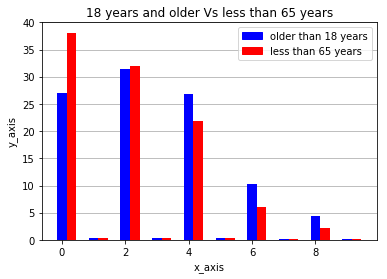

```python
row=df2.iloc[7,2:]
row1=df2.iloc[8,2:]
N=10
ind = np.arange(N)
bar_width=0.3
plt.bar(ind,row,width=bar_width, color='blue',zorder=2)
plt.bar(ind+bar_width,row1, width=bar_width, color='red',zorder=2)
plt.title("18 years and older Vs less than 65 years")
plt.xlabel('x_axis')
plt.ylabel('y_axis')
purple_patch=mpatches.Patch(color='blue',label='older than 18 years')
blue_patch=mpatches.Patch(color='red',label='less than 65 years')
plt.legend(handles=[purple_patch,blue_patch])
plt.grid(axis='y')
plt.show()
plt.show()
```

#### Inferences from above plot:

1. People with age less than 65 years have more Excellent_estimate health status in comparison to people older than 18 years.
2. There are more number of people above 18 with poor health status as compared to people belonging to age group less than 65 years.

### 18-64 years Vs 65 years and over plot

Here's barplot showing variation in health status for differnt age group.

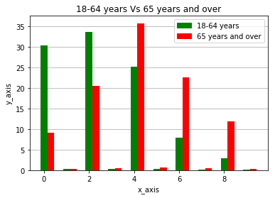

```python
row=df2.iloc[12,2:]
row1=df2.iloc[13,2:]
N=10
ind = np.arange(N)
bar_width=0.3
plt.bar(ind,row,width=bar_width, color='green',zorder=2)
plt.bar(ind+bar_width,row1, width=bar_width, color='red',zorder=2)
plt.title("18-64 years Vs 65 years and over")
plt.xlabel('x_axis')
plt.ylabel('y_axis')
purple_patch=mpatches.Patch(color='green',label='18-64 years')
blue_patch=mpatches.Patch(color='red',label='65 years and over')
plt.legend(handles=[purple_patch,blue_patch])
plt.grid(axis='y')
plt.show()
plt.show()
```

#### Inferences from above plot:

1. Less number of people have excellent health above 65 years.
2. For people older than 65 years , percentage of good health status is high, while for people b/w 18-64 years ,percent for very_good health status is high.

### Income less than 100%(poverty) Vs 200% or higher income plot:

Here's barplot showing variation of health status with differnt financila status i.e people below povery Vs 200% or more income.

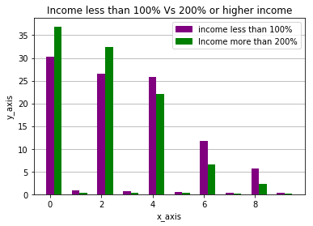

```python
row=df2.iloc[15,2:]
row1=df2.iloc[17,2:]
N=10
ind = np.arange(N)
bar_width=0.3
plt.bar(ind,row,width=bar_width, color='purple',zorder=2)
plt.bar(ind+bar_width,row1, width=bar_width, color='green',zorder=2)
plt.title("Income less than 100% Vs 200% or higher income" )
plt.xlabel('x_axis')
plt.ylabel('y_axis')
purple_patch=mpatches.Patch(color='purple',label='income less than 100%')
blue_patch=mpatches.Patch(color='green',label='Income more than 200%')
plt.legend(handles=[purple_patch,blue_patch])
plt.grid(axis='y')
plt.show()
plt.show()
```

#### Inferences from above plot:

1. Graph shows high rate of excellent health status , whose income is more than 200%, while less % of excellent health status ,who lies below poverty line.
2. More nuber of people have good health status with income less than 100%. as compared to people having income more than 200%.

### Income less than 200% VS income more than 400% plot

Here's barplot showing variations or trends w.r.t financial status of people

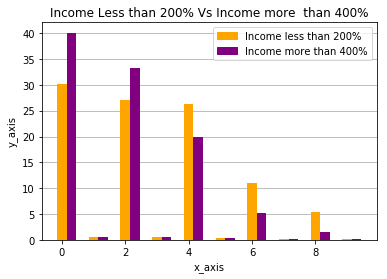

```python
row=df2.iloc[14,2:]
row1=df2.iloc[20,2:]
N=10
ind = np.arange(N)
bar_width=0.3
plt.bar(ind,row,width=bar_width, color='orange',zorder=2)
plt.bar(ind+bar_width,row1, width=bar_width, color='purple',zorder=2)
plt.title("Income Less than 200% Vs Income more  than 400%")
plt.xlabel('x_axis')
plt.ylabel('y_axis')
purple_patch=mpatches.Patch(color='orange',label='Income less than 200%')
blue_patch=mpatches.Patch(color='purple',label='Income more than 400%')
plt.legend(handles=[purple_patch,blue_patch])
plt.grid(axis='y')
plt.show()
plt.show()
```

#### Inferences from above plot:

1. Less people have excellent health status whose income is less than 200% in comparison with people whose income is more than 400%.
2. Poor health status percnetage is higher for income less than 200%

### White Vs Black non hispanic plot

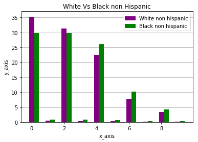

```python
row=df2.iloc[2,2:]
row1=df2.iloc[3,2:]
N=10
ind = np.arange(N)
bar_width=0.3
plt.bar(ind,row,width=bar_width, color='purple',zorder=2)
plt.bar(ind+bar_width,row1, width=bar_width, color='green',zorder=2)
plt.title("White Vs Black non Hispanic")
plt.xlabel('x_axis')
plt.ylabel('y_axis')
purple_patch=mpatches.Patch(color='purple',label='White non hispanic')
blue_patch=mpatches.Patch(color='green',label='Black non hispanic')
plt.legend(handles=[purple_patch,blue_patch])
plt.grid(axis='y')
plt.show()
plt.show()
```

#### Inferences from above plot:

1. People with white race and non hispanic origin have higher percentage of excellent health status as compared to black race and non hispanic origin.
2. People belong to white and black race shows little variation in very_good health status.

## MULTIVARIATE ANALYSIS

Multivariate data analysis refers to any statistical technique used to analyze data that arises from more than one variable,and this techniques are very valuable when working with correlated variables.

### COMPARISON B/W INCOME SUB CATEGORIES

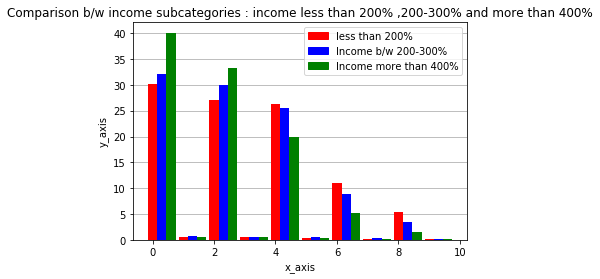

```python
row=df2.iloc[14,2:]
row1=df2.iloc[18,2:]
row2=df2.iloc[20,2:]
N=10
ind = np.arange(N)
bar_width=0.3
plt.bar(ind,row,width=bar_width, color='red',zorder=2)
plt.bar(ind+bar_width,row1, width=bar_width, color='blue',zorder=2)
plt.bar(ind+2*bar_width,row2,width=bar_width, color='green',zorder=2)
plt.title("Comparison b/w income subcategories : income less than 200% ,200-300% and more than 400%")
plt.xlabel('x_axis')
plt.ylabel('y_axis')
purple_patch=mpatches.Patch(color='red',label='less than 200%')
blue_patch=mpatches.Patch(color='blue',label='Income b/w 200-300%')
green_patch=mpatches.Patch(color='green',label='Income more than 400%')
plt.legend(handles=[purple_patch,blue_patch,green_patch])
plt.grid(axis='y')
plt.show()
plt.show()
```

#### Inferences from above plot:

1. More number of people with excellent health status, whose income is more than 400% as compared to other income sub categories.
2. More number of people have poor health status with income less than 200%

### COMPARISON B/W DIFFERENT AGE SUBCATEGORIES

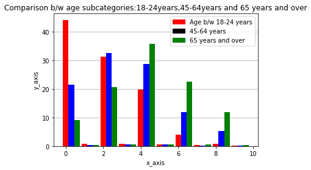

```python
row=df2.iloc[9,2:]
row1=df2.iloc[11,2:]
row2=df2.iloc[13,2:]
N=10
ind = np.arange(N)
bar_width=0.3
plt.bar(ind,row,width=bar_width, color='red',zorder=2)
plt.bar(ind+bar_width,row1, width=bar_width, color='blue',zorder=2)
plt.bar(ind+2*bar_width,row2,width=bar_width, color='green',zorder=2)
plt.title("Comparison b/w age subcategories:18-24years,45-64years and 65 years and over")
plt.xlabel('x_axis')
plt.ylabel('y_axis')
purple_patch=mpatches.Patch(color='red',label='Age b/w 18-24 years')
blue_patch=mpatches.Patch(color='black',label='45-64 years')
green_patch=mpatches.Patch(color='green',label='65 years and over')
plt.legend(handles=[purple_patch,blue_patch,green_patch])
plt.grid(axis='y')
plt.show()
plt.show()
```

#### Inferences from above plot:

1. Excellent health status percentage is high for people under age group of 18-24 years.
2. Poor health status percentage is high for people older than 65 years.
3. People older than 65years have high percentage of good health status as compared to other age group.

### COMPARISON B/W DIFFERENT RACE /OROGIN SUBCATEGORIES

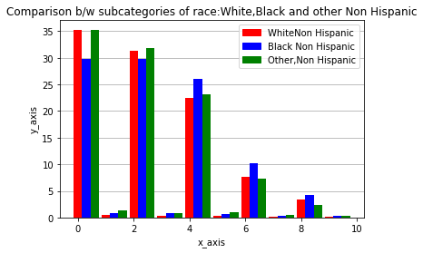

```python
row=df2.iloc[2,2:]
row1=df2.iloc[3,2:]
row2=df2.iloc[4,2:]
N=10
ind = np.arange(N)
bar_width=0.3
plt.bar(ind,row,width=bar_width, color='red',zorder=2)
plt.bar(ind+bar_width,row1, width=bar_width, color='blue',zorder=2)
plt.bar(ind+2*bar_width,row2,width=bar_width, color='green',zorder=2)
plt.title("Comparison b/w subcategories of race:White,Black and other Non Hispanic")
plt.xlabel('x_axis')
plt.ylabel('y_axis')
purple_patch=mpatches.Patch(color='red',label='WhiteNon Hispanic')
blue_patch=mpatches.Patch(color='blue',label='Black Non Hispanic')
green_patch=mpatches.Patch(color='green',label='Other,Non Hispanic')
plt.legend(handles=[purple_patch,blue_patch,green_patch])
plt.grid(axis='y')
plt.show()
plt.show()
```

## FINAL PLOT SELECTION

### MALE Vs FEMALE BARPLOT

Our bilogy allows us to escape certain health problems. However ,most health conditions affect both women and men in varying degrees due to difference in biological structure. Thus we choose Male vs female plot for final conclusion.

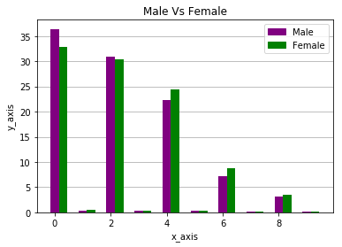

```python
row=df2.iloc[0,2:]
row1=df2.iloc[1,2:]
N=10
ind = np.arange(N)
bar_width=0.3
plt.bar(ind,row,width=bar_width, color='purple',zorder=2)
plt.bar(ind+bar_width,row1, width=bar_width, color='green',zorder=2)
plt.title("Male Vs Female")
plt.xlabel('x_axis')
plt.ylabel('y_axis')
purple_patch=mpatches.Patch(color='purple',label='Male')
blue_patch=mpatches.Patch(color='green',label='Female')
plt.legend(handles=[purple_patch,blue_patch])
plt.grid(axis='y')
plt.show()
plt.show()
```

#### Inferences from above plot:

1. Male have higher population with excellent health status than female.
2. Poor Health status percentage shows negligible variation on basis of gender characteristics.
3. Both male and female have higher population with excellent health status.
4. Female are more in number with good and fair health status as compared to male population.

### COMPARISON B/W DIFFERENT SUBCATEGORIES OF INCOME

Many factors combine together to affect the health of individuals and communities. Whether people are healthy or not,is determined by their circumstances and environment.Income and social status effect health status of person. Higher income and social status are linked to better health. The greater,the gap b/w richest and poorest people , greater the differneces in health..

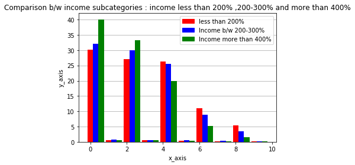

```python
row=df2.iloc[14,2:]
row1=df2.iloc[18,2:]
row2=df2.iloc[20,2:]
N=10
ind = np.arange(N)
bar_width=0.3
plt.bar(ind,row,width=bar_width, color='red',zorder=2)
plt.bar(ind+bar_width,row1, width=bar_width, color='blue',zorder=2)
plt.bar(ind+2*bar_width,row2,width=bar_width, color='green',zorder=2)
plt.title("Comparison b/w income subcategories : income less than 200% ,200-300% and more than 400%")
plt.xlabel('x_axis')
plt.ylabel('y_axis')
purple_patch=mpatches.Patch(color='red',label='less than 200%')
blue_patch=mpatches.Patch(color='blue',label='Income b/w 200-300%')
green_patch=mpatches.Patch(color='green',label='Income more than 400%')
plt.legend(handles=[purple_patch,blue_patch,green_patch])
plt.grid(axis='y')
plt.show()
plt.show()
```

#### Inferences from above plot:

1. More number of people with excellent health status whose income is more than 400% as compared to other income sub categories.
2. More number of people have poor health status with income less than 200%

### COMPARISON B/W DIFFERNET SUBCATEGORIES OF AGE

Age factor plays a very significant role in determining health status.With aging there are many changes in human body which effect health of person . People with higher age are in great risk of catching diseases.Thus we select age plot for final conclusion.

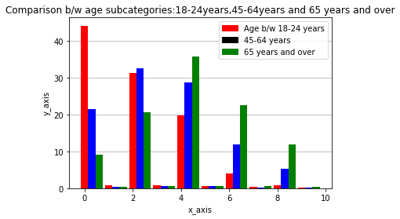

```python
row=df2.iloc[9,2:]
row1=df2.iloc[11,2:]
row2=df2.iloc[13,2:]
N=10
ind = np.arange(N)
bar_width=0.3
plt.bar(ind,row,width=bar_width, color='red',zorder=2)
plt.bar(ind+bar_width,row1, width=bar_width, color='blue',zorder=2)
plt.bar(ind+2*bar_width,row2,width=bar_width, color='green',zorder=2)
plt.title("Comparison b/w age subcategories:18-24years,45-64years and 65 years and over")
plt.xlabel('x_axis')
plt.ylabel('y_axis')
purple_patch=mpatches.Patch(color='red',label='Age b/w 18-24 years')
blue_patch=mpatches.Patch(color='black',label='45-64 years')
green_patch=mpatches.Patch(color='green',label='65 years and over')
plt.legend(handles=[purple_patch,blue_patch,green_patch])
plt.grid(axis='y')
plt.show()
plt.show()
```

#### Inferences from above plot:

1. Excellent health status percentage is high for people under age group of 18-24 years.
2. Poor health status percentage is high for people older than 65 years.
3. People older than 65years have high percentage of good health status as compared to other age group.

### CONCLUSION:

The factors which effect the health status of person are: